# 6-Clustering

# K-Means Example: Cars

We illustrate the use of k-means through the “Cars” example. First, install the required packages

```r
library(tidyverse)  # data manipulation
# install.packages("factoextra") # if necessary
library(factoextra) # clustering algorithms & visualization
library(ISLR)
set.seed(123)

df<-Auto[,c(1,6)]
summary(df)
```

```
##       mpg         acceleration
##  Min.   : 9.00   Min.   : 8.00
##  1st Qu.:17.00   1st Qu.:13.78
##  Median :22.75   Median :15.50
##  Mean   :23.45   Mean   :15.54
##  3rd Qu.:29.00   3rd Qu.:17.02
##  Max.   :46.60   Max.   :24.80
```

We will cluster cars based on mpg and acceleration. But, first, we must scale the data.

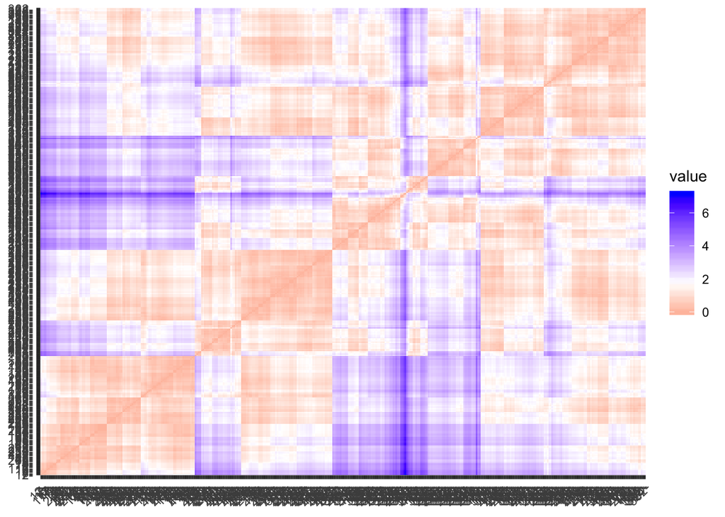

```r
# Scaling the data frame (z-score)
df <- scale(df)
distance <- get_dist(df)
fviz_dist(distance)
```

```r
k4 <- kmeans(df, centers = 4, nstart = 25) # k = 4, number of restarts = 25

# Visualize the output

k4$centers # output the centers
```

```
##          mpg acceleration
## 1 -0.4037992    0.4422649
## 2  1.0724455    1.5014548
## 3 -1.0417446   -1.0794729
## 4  0.9238892   -0.2028643
```

```r
k4$size # Number of cars in each cluster
```

```
## [1] 122  55 106 109
```

```r
k4$cluster[120] # Identify the cluster of the 120th observation as an example
```

```
## 121
##   1
```

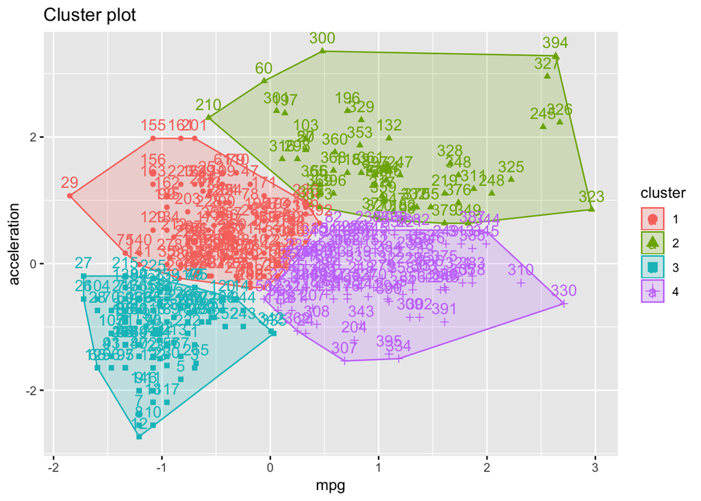

```r
fviz_cluster(k4, data = df) # Visualize the output
```

It is now easy to see that the bottom left Cluster represents cars with lower than average mpg and acceleration (negative values), while the top right Cluster represents higher than average mpg and acceleration (positive values for the centroids).

# Other Distances

Let us now rerun the example using other distances

```r
#install.packages("flexclust")
library(flexclust)
set.seed(123)
#kmeans clustering, using manhattan distance
k4 = kcca(df, k=4, kccaFamily("kmedians"))
k4
```

```
## kcca object of family 'kmedians'
##
## call:
## kcca(x = df, k = 4, family = kccaFamily("kmedians"))
##
## cluster sizes:
##
##   1   2   3   4
## 108  72 127  85
```

Let us now apply the predict function

```r
#Apply the predict() function
clusters_index <- predict(k4)
dist(k4@centers)
```

```
##          1        2        3
## 2 2.404242
## 3 1.456507 1.273868
## 4 2.728511 1.695412 1.334527
```

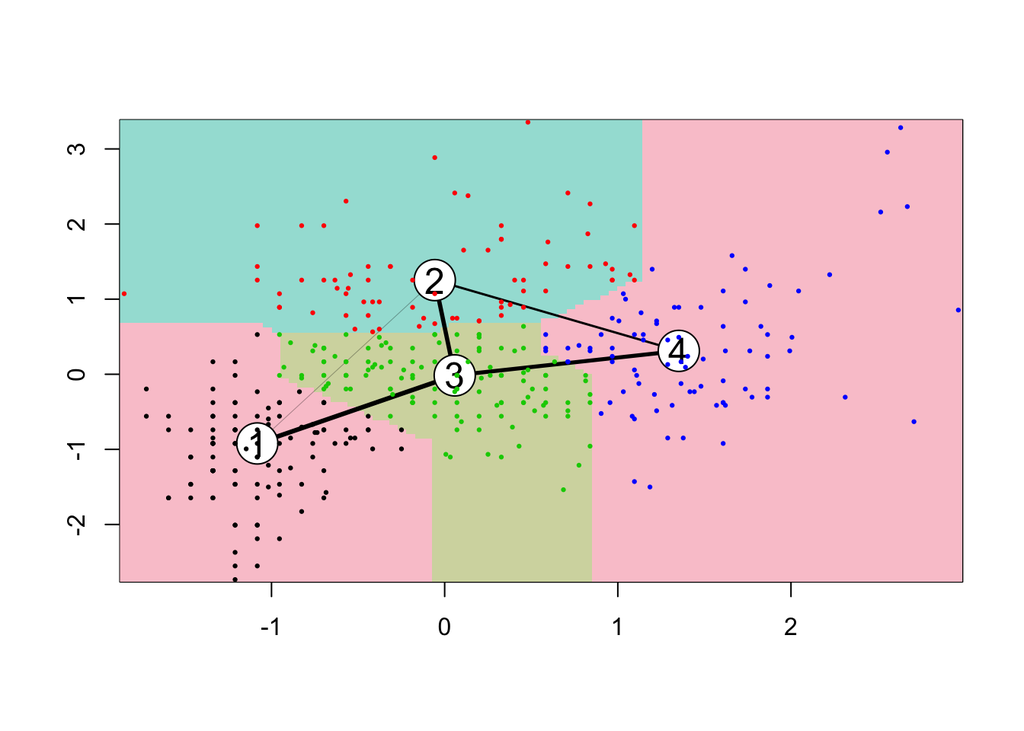

```r
image(k4)
points(df, col=clusters_index, pch=19, cex=0.3)
```

# Determining k

Let us use an “elbow chart” to determine k

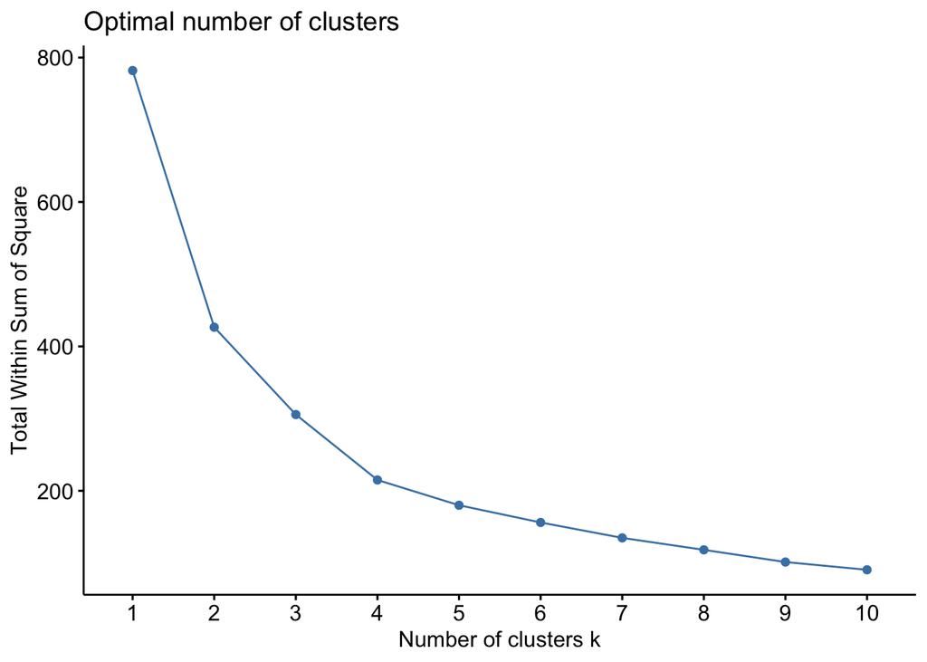

```r
library(tidyverse)  # data manipulation
library(factoextra) # clustering & visualization
library(ISLR)
set.seed(123)

df<-Auto[,c(1,6)]
# Scaling the data frame (z-score)
df <- scale(df)
fviz_nbclust(df, kmeans, method = "wss")
```

The chart shows that the elbow point 4 provides the best value for k. While WSS will continue to drop for larger values of k, we have to make the tradeoff between overfitting, i.e., a model fitting both noise and signal, to a model having bias. Here, the elbow point provides that compromise where WSS, while still decreasing beyond k = 4, decreases at a much smaller rate. In other words, adding more clusters beyond 4 brings less improvement to cluster homogeneity.

## Silhouette Method

Let us now apply the Silhouette Method to determine the number of clusters

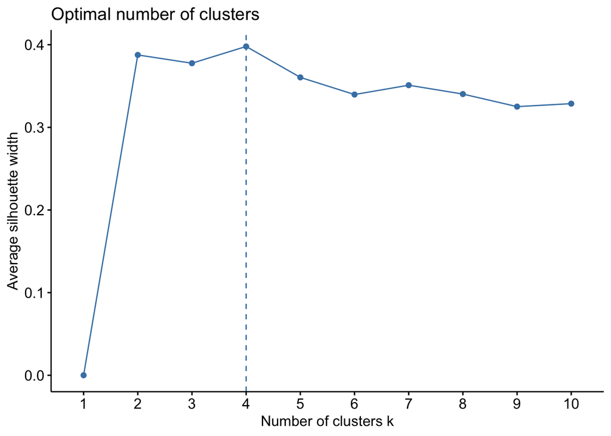

```r
fviz_nbclust(df, kmeans, method = "silhouette")
```

Again, we see that 4 is the ideal number of clusters. Here we look for large values for the Silhouette Width (Y Axis)